# $$\text{Daysi Tree}_{v0.1.0}$$

Yes, it can be done. Algorithmic Trading has the following different dimensions in it.  
You need a Quantitative Trading Model, Risk Management System, Position Sizing and Money Management System.  
**Quantitative Trading Model** - This is the heart and brain of your trading.  
You may take a simple strategy like Buy the Stock if RSI(5) > 5 and Stock P/E > XY.  
But, people have tried many simple strategies and it works at times and doesn’t work most often.  
The general consensus is you generate your own trading strategy based on Quantitative Analysis which has a good statistical probability of profit and code it into an Algorithm.  
**Risk Management System** - This is a very important part of your system just like a brake is to a high speed car.  
This will take months and even years to perfect it out and it need not be an algorithm at first.  
Just plan out something like if you buy a stock for XYZ thinking it will go XYZ+10, but rather it ends up in XYZ-10 the next day, What’s your move here?  
**Position Sizing and Money Management System** - Based on the current market level, volailtity rank this has to be adjusted.  
Pyramiding and Reverse Pyramiding should be done with every move the market makes against or with you.  
This part is often overlooked my many retail traders and they will soon burn their pockets.  
Kelly’s Criterion can be used for Position Sizing in markets. It’s a good start.  
Overall, you don’t need to be a programmer to do Algorithmic Trading. You have to be a trader who knows Programming.  
Think of trading as a game where you make your first move, then market makes the next move and so on!

```python
# IMPORTS:
import numpy as np
import random
import matplotlib
import matplotlib.pyplot as plt
import seaborn as sns
sns.set_theme("talk")
sns.set_style("white")
plt.style.use('science')
```

## $\text{Betting Strategies}$

```python
# INPUTS:
nPeriods, nTrades_perP= 365, 1
Funds= 100
pRisk= 1 # (%/100)
methodIsNormal = False
Verses = 100
```

Compound Interest

### $E[C_{t+n}]=C_0(1+{{r_k}\over{n}})^{nt}$

But this would only work if you can expect to win every time.

$\begin{equation} C_{t+1}= \begin{cases} & C_t + r_k & & \text{if you win}\\ & C_t - r_k & & \text{if you lose} \end{cases} \end{equation}$

```python
# Definitions: vars(P, Epochs, minGain, maxGain), func(betMethod(), compReal(), compExpected())
P = nPeriods*nTrades_perP
Epochs = [i/nTrades_perP for i in list(range(P+1))]
C= int(methodIsNormal)

def betMethod(choice: (0, 1)):
    if choice == 0: # Fixed Percentage
        M = random.choice([pRisk, (pRisk*-1)])/100
    if choice == 1: # Fixed Value
        M = np.random.normal(0,1)/100
    return M

def compReal():
    Bedrag = Funds
    counter = 0
    Scenarios= []
    while counter <= P:
        dailyP = betMethod(C)
        Bedrag = Bedrag*(1+dailyP)
        counter += 1
        Scenarios.append(Bedrag)
    return Scenarios

def compExpected():
    ExpectedB = Funds
    counter = 0
    ExpectedS= []
    while counter <= P:
        ExpectedB = ExpectedB*(101/100)
        counter += 1
        ExpectedS.append(ExpectedB)
    return ExpectedS
```

```
Good case scenario: end with $165 | Bad case scenario: end with $55
```

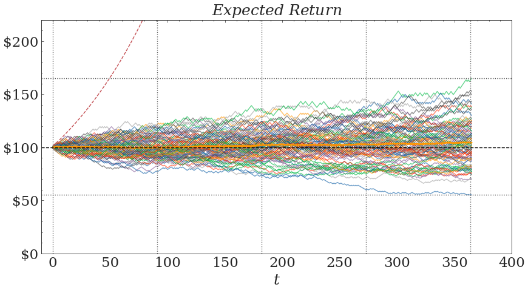

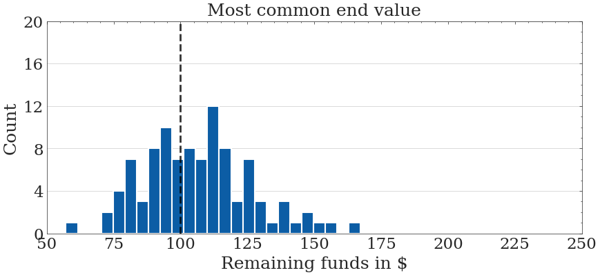

```python
fig,ax =plt.subplots()
meanScenarios= []
hist= []
maxGain= minGain= Funds

for i in range(Verses):
    Scenarios = compReal()
    ax.plot(Epochs, Scenarios, alpha=0.6)
    # Visualize range of outcomes
    A= np.max(Scenarios)
    I= np.min(Scenarios)
    if maxGain <= A: maxGain = A
    if minGain >= I: minGain = I
    meanScenarios.append([Scenarios])
    # Save for histogram later
    last = Scenarios[-1]
    hist.append(last)
ax.axhline(minGain, c="0.3", ls="dotted")
ax.axhline(maxGain, c="0.3", ls="dotted")
#Calc/Plot expected outcome
ExpectedS = compExpected()
ax2= ax.twinx()
ax2.plot(Epochs, ExpectedS, c="r", ls="--",)
ax2.get_yaxis().set_ticks([])
# Add Starting fund and mean trend // np.sum(meanScenarios, axis=0).flatten()
meanScenarios = np.sum(np.array(meanScenarios),axis=0).flatten()
meanScenarios = [x/Verses for x in meanScenarios]
ax.plot(Epochs, meanScenarios, lw=2)
ax.axhline(Funds, c="0", ls="--")

ax.vlines(range(0, P+1, int(P/4)), 0, P*20, colors="0.4", ls="dotted")
for x in (ax, ax2): x.set_ylim((0),(maxGain+ abs(0-minGain)))
for x in (ax, ax2): x.set_xlim(-10,400)
plt.title("$Expected$ $Return}$")
ax.set_xlabel('$t$')
ax.yaxis.set_major_formatter('${x:1.0f}')
print("Good case scenario: end with $%.f | Bad case scenario: end with $%.f" % (maxGain, minGain))
plt.show()

plt.figure(figsize=(10,4))
plt.title("Most common end value")
plt.hist(hist, bins=25, align='right')
plt.xlim(Funds/2, Funds*2.5)
plt.xlabel("Remaining funds in $")
plt.ylabel("Count")
plt.axvline(Funds, c="0", alpha=0.8 ,lw="2", ls="--")
plt.yticks([x for x in range(21) if x % 4 == 0])
plt.grid(axis='y')
plt.show()
```